# Learning Machine Learning

Becoming a machine learning (ML) expert is an exciting and rewarding journey, especially for an experienced software engineer like yourself. Given your background, you're already ahead with programming skills and an understanding of working with pre-trained models. Transitioning to an ML expert requires building on this foundation with specialized knowledge in machine learning concepts, algorithms, frameworks, and hands-on experience. Here's a structured path to guide your journey:

## 1. Foundational Mathematics

Understanding the mathematical underpinnings of machine learning algorithms is crucial. Focus on:

- Linear Algebra: Vectors, matrices, eigenvalues, and eigenvectors.
- Calculus: Differentiation, integration, partial derivatives, and gradient descent.
- Probability and Statistics: Probability distributions, moments, hypothesis testing, and Bayesian thinking.
- Optimization: Understanding optimization algorithms beyond just gradient descent.

## 2. Machine Learning Principles

Gain a deep understanding of core ML concepts and algorithms, including but not limited to:

- Supervised Learning: Regression, classification, support vector machines, decision trees, and neural networks.
- Unsupervised Learning: Clustering, dimensionality reduction (PCA, t-SNE), and association rules.
- Ensemble Methods: Random forests, boosting, bagging, and stacking.
- Evaluation Metrics: Accuracy, precision, recall, F1 score, ROC-AUC for classification; MSE, RMSE, MAE for regression.

## 3. Deep Learning

Deep learning is a subset of ML with its own set of algorithms and techniques:

- Neural Networks: Understanding the architecture, activation functions, and how backpropagation works.
- Convolutional Neural Networks (CNNs): For image processing, video analysis, and any data with spatial relationships.
- Recurrent Neural Networks (RNNs) and Long Short-Term Memory (LSTM) networks: For time-series analysis, natural language processing, and anything with temporal sequences.
- Generative Adversarial Networks (GANs) and Variational Autoencoders (VAEs): For generative models.
- Attention Mechanisms and Transformers: For state-of-the-art NLP models.

## 4. Programming and Tools

- Python: The de facto language for ML, with libraries such as NumPy, Pandas for data manipulation, Matplotlib and Seaborn for data visualization, and Scikit-learn for machine learning.
- TensorFlow and PyTorch: Two of the most popular deep learning frameworks. Understanding both gives you flexibility in implementing various models.
- Jupyter Notebooks: For interactive coding sessions and sharing of results.

## 5. Practical Machine Learning

- Data Preprocessing: Handling missing values, normalization, standardization, encoding categorical variables.
- Feature Engineering: Selecting, modifying, and creating new features.
- Model Selection and Tuning: Cross-validation, hyperparameter tuning with grid search and random search.
- Deployment: Understanding how to deploy models into production environments. Familiarize yourself with Docker, Flask/Django for creating APIs, and cloud services like AWS, Google Cloud, and Azure ML.

## 6. Projects and Specialization

- Work on Projects: Apply what you've learned in projects that interest you. Kaggle competitions are a great way to practice.
- Specialize: Machine learning is a vast field. You might find yourself drawn to specific areas like computer vision, natural language processing, reinforcement learning, or another niche. Dive deep into these areas.

## 7. Stay Updated and Network

- Follow Recent Research: ML is rapidly evolving. Stay updated with the latest research papers, articles, and tutorials.
- Networking: Join ML communities, attend conferences, workshops, and meetups. Engaging with the community can provide valuable learning opportunities and career connections.

## Resources to Start

- Online Courses: Coursera, Udacity, and edX offer courses from introductory to advanced levels.
- Books: "Pattern Recognition and Machine Learning" by Christopher M. Bishop for theory, "Deep Learning" by Ian Goodfellow, Yoshua Bengio, and Aaron Courville for deep learning, and "Hands-On Machine Learning with Scikit-Learn, Keras, and TensorFlow" by Aurélien Géron for practical applications.
- Websites and Blogs: Towards Data Science on Medium, arXiv for the latest papers, and the blogs of major AI research labs like OpenAI, DeepMind, and FAIR.

Starting this journey requires dedication and consistent effort. With your background, you have a strong foundation to build upon. Focus on learning systematically, applying your knowledge through projects, and continually challenging yourself with new problems.

# Hands On Learning Journey

Absolutely, I'd be delighted to guide you through your learning journey in machine learning with a hands-on approach, especially starting with Jupyter Notebook, which is a fantastic tool for experimenting with and visualizing data and machine learning models. Here’s how we can proceed in a structured, step-by-step manner:

### 1. Python Basics Refresh

Given your experience, you might already be familiar with Python, but it's always good to start with a quick refresh, specifically focusing on libraries extensively used in data science and machine learning:

- NumPy: For numerical computations and handling arrays.
- Pandas: For data manipulation and analysis.
- Matplotlib and Seaborn: For data visualization.

#### Exercise:

- Create a Jupyter notebook.
- Import these libraries to check if they are installed correctly.
- Load a CSV file using Pandas and perform basic data exploration (like viewing the first few rows of the dataset, summary statistics, etc.).

### 2. Linear Regression with Scikit-Learn

Once you're comfortable with basic data manipulation and visualization, the next step is to implement a simple machine learning model. Linear Regression is a great starting point:

#### Exercise:

- Choose a dataset with numerical features and a numerical target variable. A good example is the Boston Housing dataset.
- Use Pandas to load and explore the data.
- Preprocess the data (handle missing values, normalize/standardize if necessary).
- Split the data into training and test sets.
- Use Scikit-Learn to fit a Linear Regression model.
- Evaluate the model's performance with metrics such as Mean Squared Error (MSE) or R-squared.

### 3. Classification with Scikit-Learn

After understanding regression, you can move on to classification problems:

#### Exercise:

- Use a classification dataset like the Iris dataset.
- Perform similar steps: data exploration, preprocessing, splitting the data.
- Fit a classification model, such as Logistic Regression or a Decision Tree Classifier, using Scikit-Learn.
- Evaluate the model using classification metrics like accuracy, precision, recall, and F1-score.

### 4. Introduction to Neural Networks with TensorFlow or PyTorch

Once you've gotten a handle on basic machine learning models, you can start exploring neural networks:

#### Exercise:

- Choose a simple dataset suitable for a neural network model, such as the MNIST dataset of handwritten digits.
- Preprocess the data (normalize, reshape if necessary).
- Build a simple neural network model with an input layer, a few hidden layers, and an output layer.
- Train the model and evaluate its performance on the test set.

### 5. Projects

Projects are a great way to apply what you've learned in a practical context. Try to work on projects that interest you and span different areas of machine learning, such as:

- Natural Language Processing (NLP)
- Computer Vision
- Time Series Forecasting

For each of these steps, I can provide more detailed instructions, code examples, and help troubleshoot any issues you encounter. Let's start with the Python basics refresh exercise. Would you like to start with this, or is there a specific area you're more interested in jumping into?

# Installing and using Numpy

ME: Can you teach me about how to install and use numpy?

Let's start with a hands-on introduction to NumPy, which is a fundamental package for scientific computing in Python. NumPy provides support for arrays (including multidimensional arrays), along with a collection of mathematical functions to perform operations on these arrays. Here's how to get started:

### 1. Installation

If you haven't installed NumPy yet, you can do so using pip, Python's package manager. Open your terminal or command prompt and run:

```
pip install numpy
```

```python
pip install numpy
```

### 2. Basic Usage

Once NumPy is installed, you can start using it by importing the package into your Jupyter notebook. Here are some basic tasks to get you familiar with NumPy:

#### Starting with NumPy

In your Jupyter Notebook, import NumPy and check its version:

```
import numpy as np
print(np.__version__)
```

#### Creating Arrays

NumPy's main object is the multidimensional array. You can create a NumPy array from a Python list or tuples:

```
# Create a 1D array
arr = np.array([1, 2, 3, 4, 5])
print("1D array:\n", arr)

# Create a 2D array
arr_2d = np.array([[1, 2, 3], [4, 5, 6]])
print("\n2D array:\n", arr_2d)
```

#### Array Operations

You can perform a wide range of mathematical operations on arrays. Here are some examples:

```
# Arithmetic operations
a = np.array([1, 2, 3, 4])
b = np.array([5, 6, 7, 8])

# Addition
print("a + b =", a + b)

# Multiplication
print("a * b =", a * b)

# Square root
print("sqrt(a) =", np.sqrt(a))
```

#### Indexing and Slicing

You can access array elements through indexing and slice arrays similar to Python lists:

```
# Accessing elements
print("First element of a:", a[0])

# Slicing
print("First two elements of b:", b[:2])

# 2D array slicing
print("First row of arr_2d:", arr_2d[0])
print("Element in first row, second column:", arr_2d[0, 1])
```

#### Basic Statistics

NumPy provides functions to perform basic statistical operations on arrays:

```
data = np.array([1, 2, 3, 4, 5])

# Mean
print("Mean:", np.mean(data))

# Median
print("Median:", np.median(data))

# Standard deviation
print("Standard deviation:", np.std(data))
```

```python
import numpy as np
print(np.__version__)

# Create a 1D array
arr = np.array([1, 2, 3, 4, 5])
print("1D array:\n", arr)

# Create a 2D array
arr_2d = np.array([[1, 2, 3], [4, 5, 6]])
print("\n2D array:\n", arr_2d)

# Arithmetic operations
a = np.array([1, 2, 3, 4])
b = np.array([5, 6, 7, 8])

# Addition
print("a + b =", a + b)

# Multiplication
print("a * b =", a * b)

# Square root
print("sqrt(a) =", np.sqrt(a))

# Accessing elements
print("First element of a:", a[0])

# Slicing
print("First two elements of b:", b[:2])

# 2D array slicing
print("First row of arr_2d:", arr_2d[0])
print("Element in first row, second column:", arr_2d[0, 1])

data = np.array([1, 2, 3, 4, 5])

# Mean
print("Mean:", np.mean(data))

# Median
print("Median:", np.median(data))

# Standard deviation
print("Standard deviation:", np.std(data))
```

```
1.26.4
1D array:
 [1 2 3 4 5]

2D array:
 [[1 2 3]
 [4 5 6]]
a + b = [ 6  8 10 12]
a * b = [ 5 12 21 32]
sqrt(a) = [1.         1.41421356 1.73205081 2.        ]
First element of a: 1
First two elements of b: [5 6]
First row of arr_2d: [1 2 3]
Element in first row, second column: 2
Mean: 3.0
Median: 3.0
Standard deviation: 1.4142135623730951
```

### 3. Practice Exercise

Try the following exercise to apply what you've learned:

- Generate a random array of 10 integers between 1 and 100.
- Compute the mean, median, and standard deviation of the array.
- Create a 2D array of shape (3, 3) with random numbers.
- Access and print the second row.
- Replace the third column of the 2D array with a new column of ones.

These exercises will help you become familiar with NumPy's core concepts and prepare you for more complex operations and applications in machine learning. If you encounter any issues or have questions about specific functions or operations, feel free to ask!

```python
import numpy as np
print(np.__version__)

# Create a random array of 10 integers between 1 and 100
random_array = np.random.randint(1, 101, size=10)
print(random_array)

# Mean
print("Mean:", np.mean(random_array))

# Median
print("Median:", np.median(random_array))

# Standard deviation
print("Standard deviation:", np.std(random_array))

# Create a 2D array of random integers
random_2d = np.random.randint(1,101,size=(3, 3))
print(random_2d)

# Access and print the second row
print("Second row:", random_2d[1])

# replace the third column of the 2D array with a new column of ones
random_2d[:, 2] = 1
print(random_2d)
```

```
1.26.4
[34 63 46 45 23 40 98 27 69 72]
Mean: 51.7
Median: 45.5
Standard deviation: 22.23533224397603
[[20 49 48]
 [30 54 78]
 [84 32  6]]
Second row: [30 54 78]
[[20 49  1]
 [30 54  1]
 [84 32  1]]
```

# Installation and usage of Pandas

Let's dive into Pandas, a powerful Python library for data manipulation and analysis. Pandas is particularly well-suited for handling tabular data and offers data structures and operations for manipulating numerical tables and time series. Here's how you can get started:

### 1. Installation

First, ensure that Pandas is installed in your environment. You can install Pandas using pip, Python's package manager. Open your terminal or command prompt and execute:

```
pip install pandas
```

### 2. Basic Usage

After installing Pandas, you can start exploring its features. Here are some fundamental tasks you can perform with Pandas in your Jupyter notebook:

#### Importing Pandas

```
import pandas as pd
```

#### Creating DataFrames

Pandas DataFrame is a two-dimensional, size-mutable, and potentially heterogeneous tabular data structure with labeled axes (rows and columns). You can think of it like a spreadsheet or SQL table.

```
# Create a DataFrame from a dictionary
df = pd.DataFrame({
    'A': [1, 2, 3, 4],
    'B': ['a', 'b', 'c', 'd'],
    'C': [True, False, True, False]
})

print(df)
```

#### Reading Data

Pandas can easily read data stored in different file formats like CSV, Excel, JSON, etc. Reading a CSV file is a common operation:

```
# Example: Reading a CSV file
# df = pd.read_csv('path/to/your/file.csv')
```

#### Data Exploration

Once you have your data in a DataFrame, you can start exploring it using various functions:

```
# Display the first few rows of the DataFrame
print(df.head())

# Summary statistics for numerical columns
print(df.describe())

# Information about the DataFrame
print(df.info())
```

#### Selecting and Filtering Data

You can select specific columns or rows from a DataFrame to view or analyze them separately.

```
# Selecting a single column
print(df['A'])

# Selecting multiple columns
print(df[['A', 'B']])

# Filtering rows based on a condition
print(df[df['C'] == True])
```

#### Handling Missing Data

Pandas provides several methods to deal with missing data (NaN values), such as dropping them or filling them with a specific value.

```
# Drop rows with any NaN values
df.dropna()

# Fill NaN values with a specified value
df.fillna(value=0)
```

```python
import pandas as pd

# Create a DataFrame from a dictionary
df = pd.DataFrame({
    'A': [1, 2, 3, 4],
    'B': ['a', 'b', 'c', 'd'],
    'C': [True, False, True, False]
})

# Example: Reading a CSV file
# df = pd.read_csv('path/to/your/file.csv')

print(df)


# Display the first few rows of the DataFrame
print(df.head())

# Summary statistics for numerical columns
print(df.describe())

# Information about the DataFrame
print(df.info())


# Selecting a single column
print(df['A'])

# Selecting multiple columns
print(df[['A', 'B']])

# Filtering rows based on a condition
print(df[df['C'] == True])

# Drop rows with any NaN values
df.dropna()

# Fill NaN values with a specified value
df.fillna(value=0)
```

### 3. Practice Exercise

To apply what you've learned, try the following exercise:

- Read a CSV file into a DataFrame. You can use any CSV file you have or find an open dataset online (for example, a dataset from [Kaggle](https://www.kaggle.com/datasets)).
- Display the first 10 rows of the DataFrame.
- Print the summary statistics of the numerical columns.
- Select a column and filter the DataFrame to only include rows where the selected column's value is greater than a specific number.
- Handle any missing values in your dataset by replacing them with the mean of the column.

These steps will help you become familiar with basic data manipulation tasks in Pandas, setting a strong foundation for more complex data analysis and machine learning tasks ahead. If you have any questions or need further examples, feel free to ask!

```python
import pandas as pd

# Example: Reading a CSV file
df = pd.read_csv('data.csv')

#print(df.head(10))

# Select a column and filter the DataFrame to only include rows where the selected column's value is greater than a specific number.

# Handle any missing values in your dataset by replacing them with the mean of the column, knowing some columns may contain non-numeric data.
# Select numeric columns only
numeric_columns = df.select_dtypes(include=['number']).columns

# Calculate mean only for numeric columns
means = df[numeric_columns].mean()

# Fill NaN values in numeric columns with their respective means
df[numeric_columns] = df[numeric_columns].fillna(means)

# Optionally, fill NaN values in non-numeric columns with a placeholder
non_numeric_columns = df.select_dtypes(exclude=['number']).columns
df[non_numeric_columns] = df[non_numeric_columns].fillna('missing')

#print(df[df['Amount'] >= 0])

print(df[df['Category']== 'missing'])

#print(df.head(10))
```

# Intallation and Usage of MatplotLib and Seaborn for Data Visualization

Certainly! Matplotlib and Seaborn are two of the most popular libraries for data visualization in Python. Matplotlib is a low-level graph plotting library, offering extensive control over how elements in plots are displayed. Seaborn is built on top of Matplotlib and provides a high-level interface for drawing attractive and informative statistical graphics.

### Matplotlib

#### **Installation**

You can install Matplotlib using pip. Open your terminal or command prompt and execute:

```
pip install matplotlib
```

#### **Basic Usage**

To get started with Matplotlib in your Jupyter notebook, you can try the following examples:

```
# Importing Matplotlib
import matplotlib.pyplot as plt

# Simple plot
plt.plot([1, 2, 3, 4])
plt.ylabel('some numbers')
plt.show()
```

This code plots a simple line graph. You can customize it further by specifying both x and y coordinates, colors, plot types, etc.

#### **Plotting a Function**

```
import numpy as np

# Data for plotting
t = np.arange(0., 5., 0.2)

# Red dashes, blue squares, and green triangles
plt.plot(t, t, 'r--', t, t**2, 'bs', t, t**3, 'g^')
plt.show()
```

This example demonstrates plotting multiple functions in one graph with different styles.

### Seaborn

#### **Installation**

Similar to Matplotlib, you can install Seaborn using pip:

```
pip install seaborn
```

#### **Basic Usage**

Seaborn works well with Pandas DataFrames, making it easy to visualize data directly from your datasets:

```
# Importing Seaborn
import seaborn as sns

# Load an example dataset
tips = sns.load_dataset("tips")

# Create a simple plot
sns.relplot(x="total_bill", y="tip", data=tips)
```

This code loads a sample dataset included with Seaborn and creates a scatter plot showing the relationship between total bill and tip amount.

#### **Creating More Complex Plots**

Seaborn makes it easy to create complex plots like distribution plots, box plots, and violin plots with minimal code:

```
# Boxplot
sns.boxplot(x="day", y="total_bill", data=tips)

# Violin plot
sns.violinplot(x="day", y="total_bill", data=tips)
```

These plots provide deeper insights into the distribution of data, showcasing median, quartiles, and outliers or the distribution density.

### Practice Exercise

Try the following to apply what you've learned:

1. **Matplotlib**: Generate and plot a sine and cosine curve from -π to π. Customize the plot by adding a legend, axis labels, and a title.
2. **Seaborn**: Load the `iris` dataset from Seaborn (`sns.load_dataset('iris')`). Create a pair plot using `sns.pairplot` to visualize the relationships between its numerical columns.

These exercises will help you get hands-on experience with both libraries, making you comfortable with creating basic to more advanced visualizations. If you have any specific types of plots or visualizations in mind, feel free to ask for examples or guidance!

#### Matplotlib

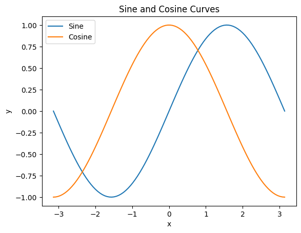

```python
import numpy as np
# Matplotlib: Generate and plot a sine and cosine curve from -π to π. Customize the plot by adding a legend, axis labels, and a title.
import matplotlib.pyplot as plt

# Generate x values from -π to π
x = np.linspace(-np.pi, np.pi, 100)

# Calculate sine and cosine values
y_sin = np.sin(x)
y_cos = np.cos(x)

# Plot the sine and cosine curves
plt.plot(x, y_sin, label='Sine')
plt.plot(x, y_cos, label='Cosine')

# Add legend, axis labels, and title
plt.legend()
plt.xlabel('x')
plt.ylabel('y')
plt.title('Sine and Cosine Curves')

# Show the plot
plt.show()
```

### Seaborn Practice

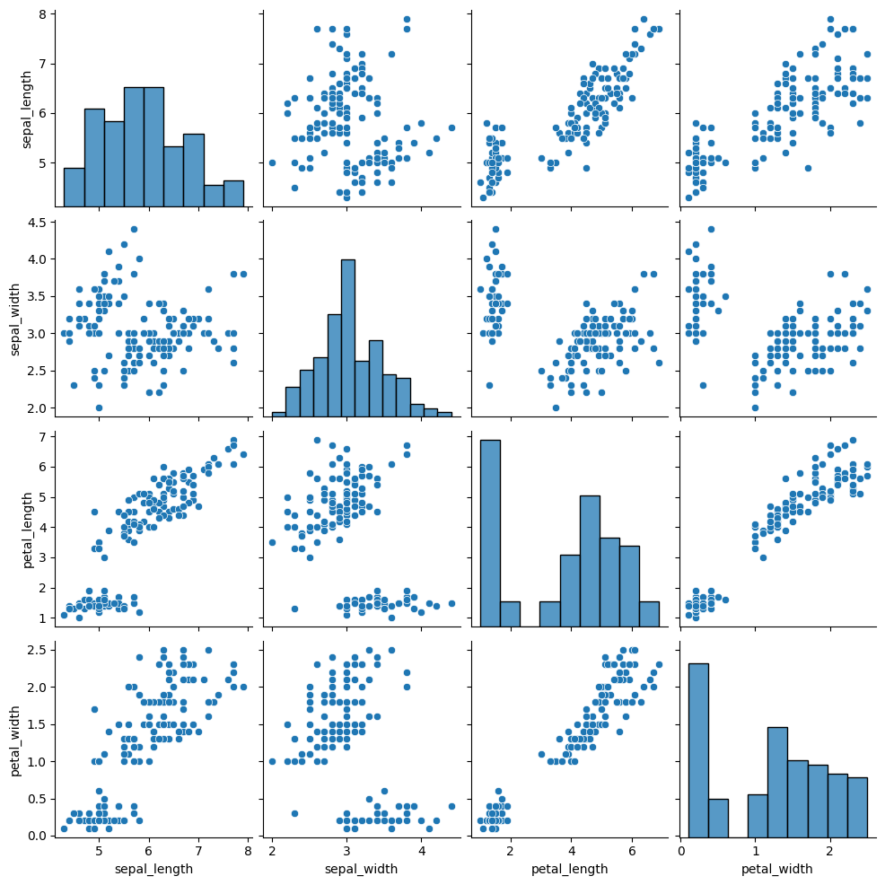

```python
# **Seaborn**: Load the `iris` dataset from Seaborn (`sns.load_dataset('iris')`). Create a pair plot using `sns.pairplot` to visualize the relationships between its numerical columns.
import seaborn as sns
iris = sns.load_dataset('iris')
sns.pairplot(iris)
```

## Test of graphing using python and copilot

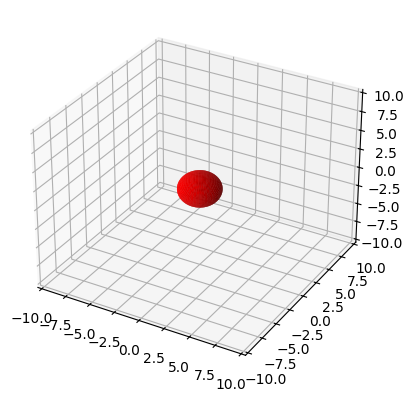

```python
import numpy as np
import matplotlib.pyplot as plt
from mpl_toolkits.mplot3d import Axes3D
import matplotlib.animation as animation

fig = plt.figure()
ax = fig.add_subplot(111, projection='3d')

# Create a sphere
u = np.linspace(0, 2 * np.pi, 100)
v = np.linspace(0, np.pi, 100)
x = 2 * np.outer(np.cos(u), np.sin(v))
y = 2 * np.outer(np.sin(u), np.sin(v))
z = 2 * np.outer(np.ones(np.size(u)), np.cos(v))

ax.set_xlim([-10, 10])
ax.set_ylim([-10, 10])
ax.set_zlim([-10, 10])

# Initialize the sphere plot
sphere = [ax.plot_surface(x, y, z, color='r')]

# Animation function
def animate(i):
    print(i)
    ax.clear()  # Clear the previous frame
    ax.set_xlim([-10, 10])
    ax.set_ylim([-10, 10])
    ax.set_zlim([-10, 10])
    sphere[0] = ax.plot_surface(x + i, y, z, color='r')  # Update the position
    return sphere

# Animate the sphere
ani = animation.FuncAnimation(fig, animate, frames=np.arange(1, 100), interval=50)
# ani.save('sphere.gif', writer='imagemagick', fps=60)

plt.show()
```

# Linear Regression with Sci-Kit Learn

You're correct, and thank you for pointing that out. The `load_boston` dataset has been deprecated and removed from scikit-learn due to ethical concerns, including considerations about consent, privacy, and the potential for misuse. As an alternative, you can use other datasets for practicing linear regression. A good substitute is the California Housing dataset, which is still included in scikit-learn and serves a similar purpose for regression tasks. Here’s how you can load the California Housing dataset and proceed with a linear regression exercise:

### Step 1: Load the California Housing Dataset

```
from sklearn.datasets import fetch_california_housing
import pandas as pd

housing = fetch_california_housing()
df = pd.DataFrame(housing.data, columns=housing.feature_names)
df['MedHouseVal'] = housing.target
```

This dataset includes features like MedInc (median income), HouseAge (housing average age), AveRooms (average rooms), AveBedrms (average bedrooms), Population, AveOccup (average occupancy), Latitude, and Longitude. The target variable is `MedHouseVal`, representing the median house value for California districts.

### Step 2: Explore, Preprocess, and Split the Data

Follow similar steps as before to explore the data, preprocess it, and split it into training and test sets. Given this dataset's structure, you might not need extensive preprocessing, but scaling the features is generally a good idea:

```
from sklearn.model_selection import train_test_split
from sklearn.preprocessing import StandardScaler

X = df.drop('MedHouseVal', axis=1)
y = df['MedHouseVal']

X_train, X_test, y_train, y_test = train_test_split(X, y, test_size=0.2, random_state=42)

scaler = StandardScaler()
X_train_scaled = scaler.fit_transform(X_train)
X_test_scaled = scaler.transform(X_test)
```

### Step 3: Fit a Linear Regression Model

```
from sklearn.linear_model import LinearRegression
from sklearn.metrics import mean_squared_error, r2_score

lr = LinearRegression()
lr.fit(X_train_scaled, y_train)
y_pred = lr.predict(X_test_scaled)
```

### Step 4: Evaluate the Model

```
mse = mean_squared_error(y_test, y_pred)
r2 = r2_score(y_test, y_pred)

print(f'Mean Squared Error: {mse:.2f}')
print(f'R-squared: {r2:.2f}')
```

This approach provides an alternative to the Boston Housing dataset for practicing linear regression with scikit-learn. The California Housing dataset is widely used for regression tasks and offers a great opportunity to work with real-world data while learning machine learning techniques.

## Code Exercises

```python
from sklearn.datasets import fetch_california_housing
import pandas as pd

housing = fetch_california_housing()
df = pd.DataFrame(housing.data, columns=housing.feature_names)
df['MedHouseVal'] = housing.target
```

```python
from sklearn.model_selection import train_test_split
from sklearn.preprocessing import StandardScaler

X = df.drop('MedHouseVal', axis=1)
y = df['MedHouseVal']

X_train, X_test, y_train, y_test = train_test_split(X, y, test_size=0.2, random_state=42)

scaler = StandardScaler()
X_train_scaled = scaler.fit_transform(X_train)
X_test_scaled = scaler.transform(X_test)
```

```python
from sklearn.linear_model import LinearRegression
from sklearn.metrics import mean_squared_error, r2_score

lr = LinearRegression()
lr.fit(X_train_scaled, y_train)
y_pred = lr.predict(X_test_scaled)
```

```python
mse = mean_squared_error(y_test, y_pred)
r2 = r2_score(y_test, y_pred)

print(f'Mean Squared Error: {mse:.2f}')
print(f'R-squared: {r2:.2f}')
```

```
Mean Squared Error: 0.56
R-squared: 0.58
```

## Simpler Explanation of Linear Regression

Imagine you're trying to predict the score you'll get on a test based on how many hours you studied. Intuitively, you might say, "The more I study, the better I'll score." Linear regression is a way to put that intuition into a mathematical form to make predictions.

### The Basics of Linear Regression:

1. **The Relationship**: At its core, linear regression examines the linear relationship between two things:
   - **Independent variable(s)**: What you control or change. In our example, this is the number of hours you studied.
   - **Dependent variable**: What you want to predict. Here, it's the test score.
2. **The Line of Best Fit**: Linear regression tries to draw a straight line through all the data points in a way that the line is as close as possible to all the points. This line is called the "line of best fit" or the regression line.

   Imagine plotting all your study hours and corresponding test scores on a graph. Each point on this graph represents a different test you've taken, showing how long you studied and what score you got. The line of best fit would run through these points in such a way that the distance from each point to the line is minimized.
3. **The Equation**: This line can be described by a simple equation: [ \text{Score} = \text{(Slope × Study Hours)} + \text{Intercept} ]
   - **Slope**: Tells you how steep the line is. In our example, it shows how much your score is expected to increase for each additional hour you study.
   - **Intercept**: Tells you where the line crosses the Y-axis. This would be the predicted score if you did not study at all.
4. **Making Predictions**: Once you have the line of best fit, you can use its equation to predict your test score based on how many hours you plan to study. For instance, if the line's equation says your score increases by 5 points for every hour you study, and the intercept is 50 points, studying for 3 hours would predict a score of: [ (5 \times 3) + 50 = 65 ] So, you'd expect to score 65 on the test.

### Simplified Explanation:

Think of linear regression as a way to draw the best straight path through a series of points on a road map, where:

- The points represent your data (like study hours and test scores).
- The straight path is the prediction model.
- The direction and steepness of the path tell you how your variables are connected (like how study time affects your score).

Just as following a straight path can help you estimate how long it'll take to reach your destination, linear regression helps you predict outcomes based on your input data.

## Plotting a Visualization of the model

Sure, I'll guide you through plotting the linear regression model using Matplotlib. Since our model involves multiple features, it's challenging to visualize it in a multi-dimensional space directly. However, for demonstration purposes, let's simplify and visualize it with one feature for clarity. We'll choose a single feature (e.g., `MedInc`, median income) from the California Housing dataset to predict the median house value (`MedHouseVal`).

First, let's create a linear regression model using only the `MedInc` feature to predict `MedHouseVal`. Then, we'll plot this model's predictions against our data.

### Step 1: Simplify the Model for Visualization

We'll modify the model to use just one feature (`MedInc`) for simplicity and visualization purposes.

```
import numpy as np
import pandas as pd
import matplotlib.pyplot as plt
from sklearn.datasets import fetch_california_housing
from sklearn.linear_model import LinearRegression
from sklearn.model_selection import train_test_split
from sklearn.preprocessing import StandardScaler

# Load the dataset
housing = fetch_california_housing()
df = pd.DataFrame(housing.data, columns=housing.feature_names)
df['MedHouseVal'] = housing.target

# Use only the 'MedInc' feature
X = df[['MedInc']]
y = df['MedHouseVal']

# Split the data into training and test sets
X_train, X_test, y_train, y_test = train_test_split(X, y, test_size=0.2, random_state=42)

# Standardizing the feature (though for a single feature, this step could be optional)
scaler = StandardScaler()
X_train_scaled = scaler.fit_transform(X_train)
X_test_scaled = scaler.transform(X_test)

# Fit the Linear Regression model
model = LinearRegression()
model.fit(X_train_scaled, y_train)

# Predictions for the test set
y_pred = model.predict(X_test_scaled)
```

### Step 2: Plot the Data and the Model

Now, let's plot the test data and the linear regression model to visualize how well our model fits the data.

```
# Plotting the test data
plt.figure(figsize=(10, 6))
plt.scatter(X_test_scaled, y_test, color='blue', label='Actual values')

# Plotting the regression line
# Generate a range of values from min to max income for plotting the line
x_line = np.linspace(X_test_scaled.min(), X_test_scaled.max(), 100)
# Predict y values for these x values using our trained model
y_line = model.predict(x_line.reshape(-1, 1))

plt.plot(x_line, y_line, color='red', label='Linear regression model')

plt.title('Linear Regression Model vs. Actual Values')
plt.xlabel('Median Income (Standardized)')
plt.ylabel('Median House Value')
plt.legend()
plt.show()
```

This visualization will show you the scatter plot of the actual house values versus the median income (on a standardized scale) and the linear regression line that predicts the median house value from the median income. The closer the points are to the line, the better your model is at predicting the house values based on the income feature.

### Running the Plot

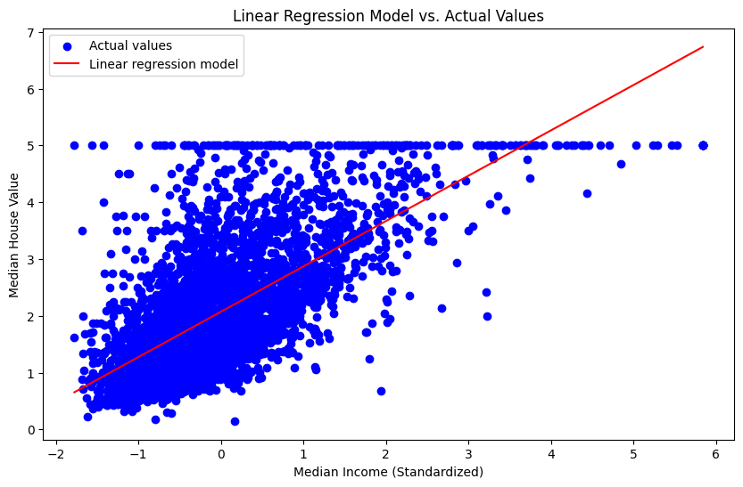

```python
import numpy as np
import pandas as pd
import matplotlib.pyplot as plt
from sklearn.datasets import fetch_california_housing
from sklearn.linear_model import LinearRegression
from sklearn.model_selection import train_test_split
from sklearn.preprocessing import StandardScaler

# Load the dataset
housing = fetch_california_housing()
df = pd.DataFrame(housing.data, columns=housing.feature_names)
df['MedHouseVal'] = housing.target

# Use only the 'MedInc' feature
X = df[['MedInc']]
y = df['MedHouseVal']

# Split the data into training and test sets
X_train, X_test, y_train, y_test = train_test_split(X, y, test_size=0.2, random_state=42)

# Standardizing the feature (though for a single feature, this step could be optional)
scaler = StandardScaler()
X_train_scaled = scaler.fit_transform(X_train)
X_test_scaled = scaler.transform(X_test)

# Fit the Linear Regression model
model = LinearRegression()
model.fit(X_train_scaled, y_train)

# Predictions for the test set
y_pred = model.predict(X_test_scaled)

# Plotting the test data
plt.figure(figsize=(10, 6))
plt.scatter(X_test_scaled, y_test, color='blue', label='Actual values')

# Plotting the regression line
# Generate a range of values from min to max income for plotting the line
x_line = np.linspace(X_test_scaled.min(), X_test_scaled.max(), 100)
# Predict y values for these x values using our trained model
y_line = model.predict(x_line.reshape(-1, 1))

plt.plot(x_line, y_line, color='red', label='Linear regression model')

plt.title('Linear Regression Model vs. Actual Values')
plt.xlabel('Median Income (Standardized)')
plt.ylabel('Median House Value')
plt.legend()
plt.show()
```

The graph you're looking at is a scatter plot showing the relationship between the standardized median income of households and their corresponding median house values in the California housing dataset. The red line represents the linear regression model that has been fitted to the data.

#### What is Standardized Median Income?

Standardization is a technique used to scale numerical data to have a mean of zero and a standard deviation of one. This process transforms the data into a form where you can more easily compare values and apply certain statistical techniques, especially in machine learning.

When you standardize a variable like median income, you subtract the mean of all median incomes from each individual median income and then divide by the standard deviation of all median incomes. The result is a **standardized median income**, often called a z-score. This tells you how many standard deviations a particular value is from the mean.

Here’s the formula for standardizing a value ( x ):

[ z = \frac{(x - \mu)}{\sigma} ]

where:

- ( z ) is the standardized score.
- ( x ) is the original value.
- ( \mu ) is the mean of the dataset.
- ( \sigma ) is the standard deviation of the dataset.

#### How It Relates to Your Household

If you want to understand how your own household's median income compares to the dataset used for the California housing model, you would:

1. Find out the mean (average) median income and the standard deviation of median incomes in the dataset.
2. Take your own household's median income.
3. Plug your household's median income into the standardization formula using the dataset's mean and standard deviation.

The resulting z-score will tell you where your household income falls in relation to the average of the dataset:

- A **positive z-score** means your income is above the average.
- A **negative z-score** means your income is below the average.
- A z-score around **zero** means your income is close to the average.

For example, if your z-score was 2, your household's median income would be two standard deviations above the mean of the dataset.

It’s important to note that the "median" income refers to the middle value when all incomes are listed in order; it is not the same as the "average" income. The use of median helps to reduce the impact of extremely high or low incomes on the overall income estimation, providing a better representation of a typical household's income.

Certainly! Below is a step-by-step lesson for performing classification using scikit-learn with the famous Iris dataset.

# Classification with Scikit-Learn Using the Iris Dataset

## Introduction to Classification with Scikit-Learn

Welcome to your lesson on classification using scikit-learn in Python. In machine learning, classification is a type of supervised learning approach that is used to predict the category of data points. In simpler terms, classification algorithms help us to decide which category, or class, an object belongs to based on its features.

### What is Supervised Learning?

Supervised learning involves training a model on a labeled dataset, which means that each training example is paired with an output label. The model learns from these examples to make predictions on unseen data.

### What is Classification?

Classification models are used to predict discrete responses. For example, classifying emails as 'spam' or 'not spam', or medical diagnoses as 'disease' or 'no disease'. These responses are known as classes.

In this lesson, we'll focus on a famous dataset called the Iris dataset. It contains 150 observations of iris flowers from three different species. Each observation has four features: the length and the width of sepals and petals.

Our goal is to build a model that can predict the species of an iris using these features.

### Steps We Will Follow:

1. **Data Exploration**: Understanding your data is essential. We'll look at the Iris dataset using Pandas, which will help us to see how our data is structured and give us insights that will be useful for later steps.
2. **Data Preprocessing**: Before feeding the data into a machine learning algorithm, we often need to preprocess it. This may involve splitting the dataset into "features" and "labels", dealing with missing values, and scaling the features.
3. **Train-Test Split**: We will divide our dataset into two parts: one for training our model and the other for testing its performance. This helps us evaluate how well our model will perform on new, unseen data.
4. **Model Selection and Training**: We'll choose a classification algorithm and use it to learn the patterns in our training data. In this lesson, we're going to use Logistic Regression, which, despite its name, is a classification algorithm.
5. **Model Evaluation**: We'll make predictions on our test data and use metrics such as accuracy, precision, recall, and the F1 score to evaluate how well our model performs. These metrics give us a more nuanced view of the model's performance than accuracy alone.
6. **Visualization**: We'll use a confusion matrix to visualize the performance of our model. This will show us the true positives, false positives, true negatives, and false negatives of our predictions.

By the end of this lesson, you should have a basic understanding of how to perform classification using scikit-learn, evaluate your models, and visualize their performance. Let's get started!

## Step 1: Import Necessary Libraries

Before we dive into the code and start our classification task, we need to ensure that we have all the necessary tools at our disposal. In Python, these tools come in the form of libraries—collections of functions and methods that allow us to perform many actions without writing the code from scratch.

```
import numpy as np
import pandas as pd
from sklearn.datasets import load_iris
from sklearn.model_selection import train_test_split
from sklearn.preprocessing import StandardScaler
from sklearn.linear_model import LogisticRegression
from sklearn.metrics import accuracy_score, precision_score, recall_score, f1_score, confusion_matrix
import seaborn as sns
import matplotlib.pyplot as plt
```

## Step 2: Load and Explore the Dataset

In this section, we embark on a crucial phase of any data science project: loading and getting familiar with the dataset. The Iris dataset, a classic in the field of machine learning, serves as our starting point. Comprising 150 samples across three different species of Iris flowers, the dataset includes four feature variables: sepal length, sepal width, petal length, and petal width. Our objective is to predict the species of each flower based on these measurements.

By loading the data into our environment and converting it into a pandas DataFrame, we position ourselves to effectively manipulate and visualize the data. This step transforms our abstract dataset into a structured format that is not only easy to work with but also more intuitive to understand. Pandas DataFrames provide us with a two-dimensional, labeled data structure with columns that can be of different types, much like SQL tables or Excel spreadsheets. Here, each row represents an observation (a flower in this case), and each column represents a feature that describes the observation.

With the data neatly tabulated, we’ll proceed to preview the first few entries using iris_df.head(). This glimpse into the dataset affords us an initial check on the types of data, range of values, and presence of any anomalies that may warrant a closer look. Following this, we employ iris_df.describe() to generate descriptive statistics that summarize the central tendency, dispersion, and shape of the dataset’s distribution. Notably absent in this automated process is the tedious effort that traditionally accompanied such exploratory data analysis. With these tools at our disposal, we are well-equipped to uncover insights that will inform our subsequent steps in building a predictive model.

```
# Load the Iris dataset
iris = load_iris()
X = iris.data
y = iris.target

# Convert to DataFrame for easier data manipulation and visualization
iris_df = pd.DataFrame(X, columns=iris.feature_names)
iris_df['species'] = pd.Categorical.from_codes(iris.target, iris.target_names)

# Display the first few rows
print(iris_df.head())

# Summary statistics
print(iris_df.describe())

# Check for missing values
print(iris_df.isnull().sum())
```

## Step 3: Preprocess the Data

### Explainer

Before we feed our Iris dataset into a machine learning model, it's essential to preprocess the data. This stage involves two key steps: splitting the dataset and feature scaling.

#### Splitting the Dataset:

The first part of preprocessing is to split our dataset into two parts: the training set and the testing set.

```
X_train, X_test, y_train, y_test = train_test_split(X, y, test_size=0.2, random_state=42)
```

Here, `train_test_split` is a function from scikit-learn that divides our data into a training set and a test set. The training set is what we'll use to train our model, teaching it about the relationships between the features and the labels. The test set is held back and not used during training. It acts as new, unseen data to evaluate how well our model can predict the labels based on the features.

The `test_size=0.2` parameter tells the function to reserve 20% of the data for testing, which means 80% is used for training. The `random_state=42` parameter ensures that the split is reproducible; if you run the code multiple times, it will produce the same split each time, which is helpful for consistent results.

#### Standardizing the Features:

After splitting the data, we turn our attention to feature scaling, a method used to standardize the range of features in the data.

```
scaler = StandardScaler()
X_train_scaled = scaler.fit_transform(X_train)
X_test_scaled = scaler.transform(X_test)
```

The `StandardScaler` standardizes features by removing the mean and scaling to unit variance. This is done by subtracting the mean value of each feature and then dividing it by the standard deviation.

Why do this? Many machine learning algorithms perform better when numerical input variables are on a similar scale and close to normally distributed. Standardizing helps to achieve this by making sure that each feature contributes approximately proportionately to the final distance.

The `fit_transform` method computes the mean and standard deviation and scales the training data accordingly. We then use the `transform` method to apply the same transformation to the test data. It's crucial to use the same scaling for both training and test data to ensure consistency in how we're presenting the data to the model.

By preprocessing our data this way, we're setting the stage for more effective and accurate model training.

Here is the code for standardizing the features.

```
# Split the data into training and testing sets
X_train, X_test, y_train, y_test = train_test_split(X, y, test_size=0.2, random_state=42)

# Standardize the features
scaler = StandardScaler()
X_train_scaled = scaler.fit_transform(X_train)
X_test_scaled = scaler.transform(X_test)
```

## Step 4: Fit a Classification Model

### Explainer

After our data is preprocessed, we're ready to move on to building the actual machine learning model. In this step, we're going to use a Logistic Regression model for our classification task.

#### Initializing the Model:

```
logreg = LogisticRegression(random_state=42)
```

Here, we create an instance of the `LogisticRegression` class from scikit-learn and assign it to the variable `logreg`. This object represents our logistic regression model. We set the `random_state` parameter to a fixed number to ensure the reproducibility of our results. The `random_state` works like a seed in a random number generator, making sure that the stochastic process of learning the model can be replicated.

#### Fitting the Model:

```
logreg.fit(X_train_scaled, y_train)
```

The `fit` method is one of the core aspects of scikit-learn's machine learning estimators. It takes the training data and the training labels as input and 'fits' the model to the data. In simpler terms, this is where the logistic regression model learns the relationship between the features (the scaled measurements of the iris flowers) and the labels (the species of the flowers). It does this by finding parameters (coefficients and intercept) that best map the features to the labels.

Once this command is executed, the `logreg` model is trained and ready to make predictions. In the context of logistic regression, 'fitting' involves finding the best boundary that separates the classes. In the case of the Iris dataset, since there are three classes, logistic regression will internally fit multiple one-vs-rest classifiers and combine their results to predict the classes.

```
# Initialize the Logistic Regression model
logreg = LogisticRegression(random_state=42)

# Fit the model to the training data
logreg.fit(X_train_scaled, y_train)
```

## Step 5: Make Predictions and Evaluate the Model

### Explainer

After training our Logistic Regression model, the next crucial step is to use it to make predictions and then evaluate how well our model is performing. This step is all about assessing the model's ability to accurately predict the labels of new data points it hasn't seen before, using the test set we set aside earlier.

#### Making Predictions:

```
y_pred = logreg.predict(X_test_scaled)
```

Using the `predict` method of our trained `logreg` model, we make predictions on the scaled test data (`X_test_scaled`). The method returns a predicted label for each instance in the test set, which we store in `y_pred`. These predictions can then be compared to the actual labels (`y_test`) to see how many the model got right.

#### Evaluating the Model:

Next, we calculate various metrics that give us insight into the model's performance:

```
accuracy = accuracy_score(y_test, y_pred)
```

- **Accuracy**: It tells us the proportion of the total number of predictions that were correct. It is a useful metric when the target classes are well balanced.

```
precision = precision_score(y_test, y_pred, average='macro')
recall = recall_score(y_test, y_pred, average='macro')
f1 = f1_score(y_test, y_pred, average='macro')
```

- **Precision**: It indicates the proportion of positive identifications that were actually correct. High precision relates to a low false positive rate.
- **Recall**: It shows the proportion of actual positives that were identified correctly. High recall relates to a low false negative rate.
- **F1 Score**: This is the harmonic mean of precision and recall and gives a single score that balances both the concerns of precision and recall in one number.

These metrics are particularly important in situations where we have imbalanced classes—where the cost of a false positive might differ from the cost of a false negative.

#### Visualization with a Confusion Matrix:

Finally, we create a confusion matrix—a table used to describe the performance of a classification model:

```
cm = confusion_matrix(y_test, y_pred)
sns.heatmap(cm, annot=True, fmt='d')
```

This matrix shows us exactly where the model is getting things right and where it's making mistakes. Each cell in the matrix represents a combination of predicted and actual classes. For example, the cell in the top-left corner represents the number of times the model predicted class 0 and the true label was also class 0 (true positives for class 0). By visualizing this matrix with Seaborn's heatmap, we can quickly grasp how well our model is performing across all classes.

Together, these steps of making predictions and evaluating the model form a feedback loop for the data scientist, providing critical information that can be used to improve the model in future iterations.

```
# Make predictions on the test set
y_pred = logreg.predict(X_test_scaled)

# Calculate the accuracy
accuracy = accuracy_score(y_test, y_pred)
print(f'Accuracy: {accuracy:.2f}')

# Calculate precision, recall, and F1-score
precision = precision_score(y_test, y_pred, average='macro')
recall = recall_score(y_test, y_pred, average='macro')
f1 = f1_score(y_test, y_pred, average='macro')
print(f'Precision: {precision:.2f}')
print(f'Recall: {recall:.2f}')
print(f'F1 Score: {f1:.2f}')

# Confusion matrix
cm = confusion_matrix(y_test, y_pred)
sns.heatmap(cm, annot=True, fmt='d')
plt.xlabel('Predicted')
plt.ylabel('True')
plt.show()
```

In this lesson, you:

- Loaded the Iris dataset, which contains 3 classes of 50 instances each, where each class refers to a type of iris plant.
- Explored the dataset using Pandas DataFrame methods.
- Preprocessed the data by splitting it into a training set and a test set and standardizing the features.
- Used Logistic Regression as the classification model, trained it with the training set, and made predictions on the test set.
- Evaluated the model's performance with several metrics: accuracy, precision, recall, and F1-score.
- Visualized the confusion matrix using Seaborn to see how well the model performed on each class.

This exercise covers the key steps of performing classification in machine learning. You can copy these code snippets into your Jupyter notebook and run them cell by cell to walk through the classification process. If you have any questions about the steps or the code, feel free to ask!

## Exercises

```python
import numpy as np
import pandas as pd
from sklearn.datasets import load_iris
from sklearn.model_selection import train_test_split
from sklearn.preprocessing import StandardScaler
from sklearn.linear_model import LogisticRegression
from sklearn.metrics import accuracy_score, precision_score, recall_score, f1_score, confusion_matrix
import seaborn as sns
import matplotlib.pyplot as plt
```

```python
# Load the Iris dataset
iris = load_iris()
X = iris.data
y = iris.target

# Convert to DataFrame for easier data manipulation and visualization
iris_df = pd.DataFrame(X, columns=iris.feature_names)
iris_df['species'] = pd.Categorical.from_codes(iris.target, iris.target_names)

# Display the first few rows
print(iris_df.head())

# Summary statistics
print(iris_df.describe())

# Check for missing values
print(iris_df.isnull().sum())
```

```
   sepal length (cm)  sepal width (cm)  petal length (cm)  petal width (cm)  \
0                5.1               3.5                1.4               0.2
1                4.9               3.0                1.4               0.2
2                4.7               3.2                1.3               0.2
3                4.6               3.1                1.5               0.2
4                5.0               3.6                1.4               0.2

  species
0  setosa
1  setosa
2  setosa
3  setosa
4  setosa
       sepal length (cm)  sepal width (cm)  petal length (cm)  \
count         150.000000        150.000000         150.000000
mean            5.843333          3.057333           3.758000
std             0.828066          0.435866           1.765298
min             4.300000          2.000000           1.000000
25%             5.100000          2.800000           1.600000
50%             5.800000          3.000000           4.350000
75%             6.400000          3.300000           5.100000
max             7.900000          4.400000           6.900000

       petal width (cm)
count        150.000000
mean           1.199333
std            0.762238
min            0.100000
25%            0.300000
50%            1.300000
75%            1.800000
max            2.500000
sepal length (cm)    0
sepal width (cm)     0
petal length (cm)    0
petal width (cm)     0
species              0
dtype: int64
```

```python
# Split the data into training and testing sets
X_train, X_test, y_train, y_test = train_test_split(X, y, test_size=0.2, random_state=42)

# Standardize the features
scaler = StandardScaler()
X_train_scaled = scaler.fit_transform(X_train)
X_test_scaled = scaler.transform(X_test)
```

```python
# Initialize the Logistic Regression model
logreg = LogisticRegression(random_state=42)

# Fit the model to the training data
logreg.fit(X_train_scaled, y_train)
```

```
LogisticRegression(random_state=42)
```

```
Accuracy: 1.00
Precision: 1.00
Recall: 1.00
F1 Score: 1.00
```

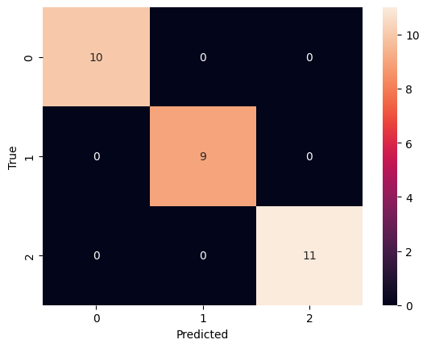

```python
# Make predictions on the test set
y_pred = logreg.predict(X_test_scaled)

# Calculate the accuracy
accuracy = accuracy_score(y_test, y_pred)
print(f'Accuracy: {accuracy:.2f}')

# Calculate precision, recall, and F1-score
precision = precision_score(y_test, y_pred, average='macro')
recall = recall_score(y_test, y_pred, average='macro')
f1 = f1_score(y_test, y_pred, average='macro')
print(f'Precision: {precision:.2f}')
print(f'Recall: {recall:.2f}')
print(f'F1 Score: {f1:.2f}')

# Confusion matrix
cm = confusion_matrix(y_test, y_pred)
sns.heatmap(cm, annot=True, fmt='d')
plt.xlabel('Predicted')
plt.ylabel('True')
plt.show()
```

# Chapter 4: Introduction to Neural Networks with TensorFlow

## Understanding Neural Networks

Neural networks are a set of algorithms, modeled loosely after the human brain, designed to recognize patterns. They interpret sensory data through a kind of machine perception, labeling, or clustering raw input. The patterns they recognize are numerical, contained in vectors, into which all real-world data, be it images, sound, text, or time series, must be translated.

### Key Concepts of Neural Networks:

- **Neurons**: The basic unit of computation in a neural network. Each neuron receives input, processes it, and generates an output.
- **Layers**: A neural network consists of layers. The first layer is the input layer, the last layer is the output layer, and in between, there are zero or more hidden layers.
- **Weights and Biases**: Neurons in a neural network have weights and biases, parameters that are adjusted through the training process.
- **Activation Function**: A function that is applied to the output of each neuron. It decides whether a neuron should be activated or not, adding non-linearity to the model.

## Building a Neural Network with TensorFlow

TensorFlow is an open-source software library for dataflow and differentiable programming across a range of tasks, and it's particularly suited for neural networks.

### Exercise: Recognizing Handwritten Digits with the MNIST Dataset

The MNIST dataset is a collection of 70,000 handwritten digits split into a training set and a test set. Each image is 28x28 pixels, and each pixel is a feature.

#### Preprocessing the Data:

Before we can use the MNIST dataset to train a neural network, we need to preprocess the data:

- **Normalization**: This process scales pixel values from a range of 0-255 to a range of 0-1, which helps the neural network learn more efficiently.
- **Reshaping**: Neural networks expect a certain input shape, so we often need to reshape our data to fit this expectation.

#### Building the Neural Network Model:

```
import tensorflow as tf

# Define the model
model = tf.keras.models.Sequential([
    tf.keras.layers.Flatten(input_shape=(28, 28)),
    tf.keras.layers.Dense(128, activation='relu'),
    tf.keras.layers.Dense(10, activation='softmax')
])
```

- **Input Layer**: `Flatten` turns the 28x28 image into a 1D array of 784 pixels.
- **Hidden Layer**: A `Dense` layer with 128 neurons and ReLU (Rectified Linear Unit) activation function.
- **Output Layer**: A `Dense` layer with 10 neurons (one for each digit) with softmax activation, which is used for multi-class classification.

#### Compiling the Model:

```
model.compile(optimizer='adam',
              loss='sparse_categorical_crossentropy',
              metrics=['accuracy'])
```

- **Optimizer**: Adam is a popular optimization algorithm for training neural networks.
- **Loss Function**: Since we're dealing with a classification problem, we use `sparse_categorical_crossentropy` to calculate the loss.
- **Metrics**: We're interested in tracking accuracy during training and testing.

#### Training the Model:

```
history = model.fit(x_train, y_train, epochs=10, validation_data=(x_test, y_test))
```

- We train the model using the `fit` method, passing in the training data and labels. The `epochs` parameter specifies how many times the model should go through the dataset.

#### Evaluating the Model:

```
test_loss, test_acc = model.evaluate(x_test, y_test, verbose=2)
print('\nTest accuracy:', test_acc)
```

- After training, we evaluate the model on the test set to see how well it performs on new, unseen data.

### Conclusion

Neural networks are a powerful tool in machine learning, capable of performing a wide variety of tasks that were previously considered challenging for machines. With libraries like TensorFlow, it has never been easier to start building and experimenting with these models.